# Etude exuvies RN Vosges - Préparation plan d’échantillonnage état-zéro

Thibaut Couturier

Analyse en date du 2024-11-19

On importe les cartographies d’habitats utilisées lors de l’échantillonnage de l’étude-pilote. On y applique un nouveau regroupement, discuté entre les partenaires (Alix, Marjolaine et Thibault) le **18 mai 2022**.

On importe les tableaux de données collectées lors de l’étude-pilote. Parmi les modifications/transformations de ce jeu de données, on précise notamment le nouveau regroupement d’habitat proposé en mai 2022.

On importe également les fichiers de données SIG des placettes réalisées lors de l’étude-pilote de 2021. On projette ces placettes sur les cartographies d’habitats. Les valeurs manquantes (NA) correspondent aux habitats qui sont exclus du nouveau plan d’échantillonnage.

TGF

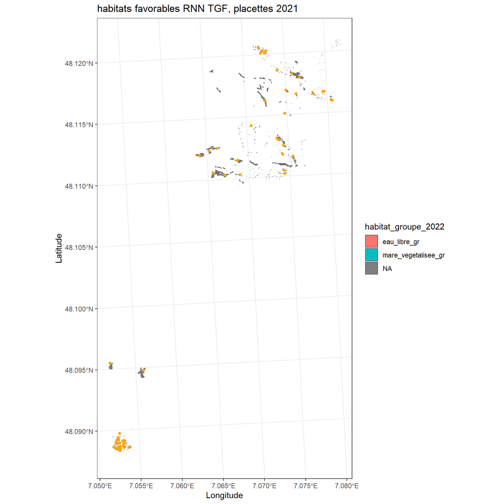

TDC

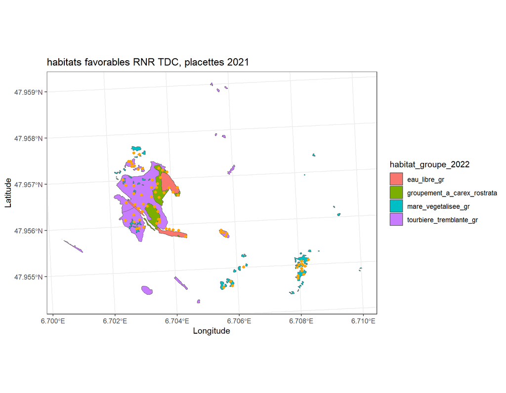

TDM

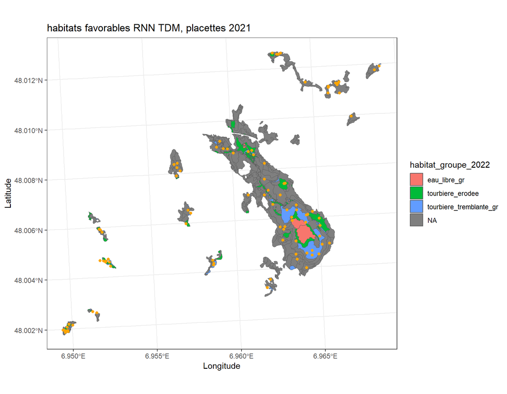

Le tableau suivant fournit le bilan du nombre d’exuvies collectées et de placettes échantillonnées en 2021 par catégorie d’habitat (nouveau regroupement de mai 2022). A noter que les placettes situées dans les zones périphériques de TDM ont préalablement été exclues (non échantillonnées en 2022).

| habitat_groupe_2022 | tot_exuvies_TDC | tot_exuvies_TGF | tot_exuvies_RNM | tot_placettes_TDC | tot_placettes_TGF | tot_placettes_RNM |
| --- | --- | --- | --- | --- | --- | --- |
| eau_libre_gr | 149 | 76 | 62 | 11 | 26 | 10 |
| groupement_a_carex_rostrata | 114 | 0 | 0 | 15 | 0 | 0 |
| mare_vegetalisee_gr | 1 | 0 | 0 | 16 | 6 | 0 |
| tourbiere_erodee | 0 | 0 | 5 | 0 | 0 | 10 |
| tourbiere_tremblante_gr | 3 | 0 | 38 | 29 | 0 | 10 |
| NA | 0 | 1 | 1 | 5 | 31 | 21 |

On joint les infos relatives aux habitats regroupés dans le fichier de données collectées lors de l’étude-pilote au fichier de données SIG correspondant aux localités des placettes.

On tire des placettes de manière systématique au sein des différents types d’habitats étudiés.

On les projette sur cartes

TDM

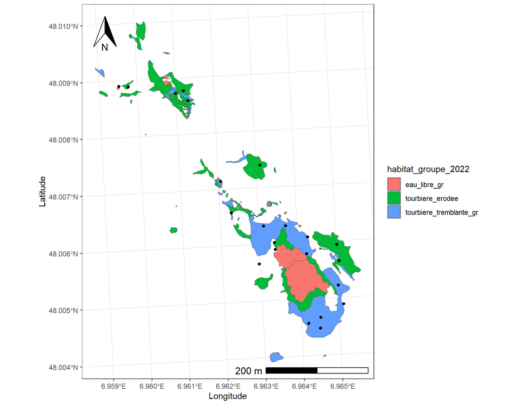

TDC

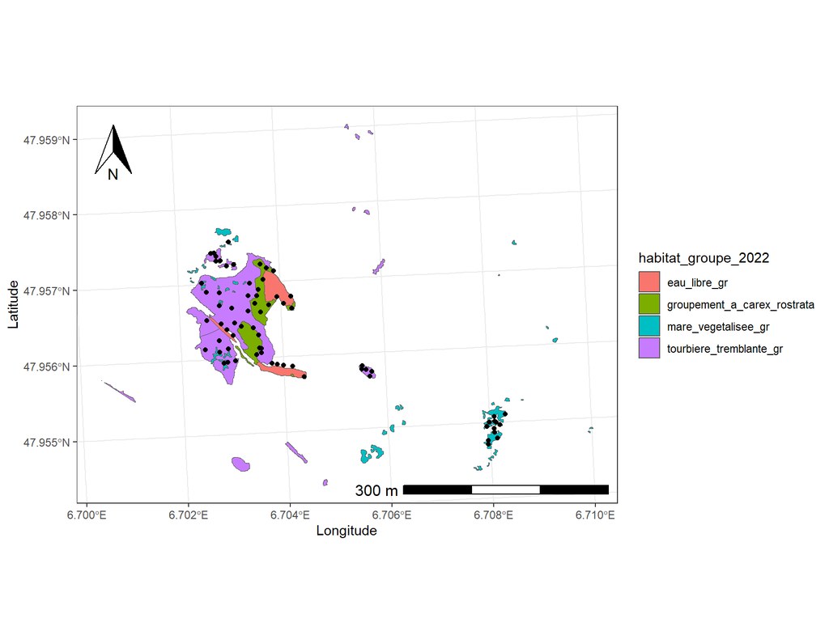

TGF

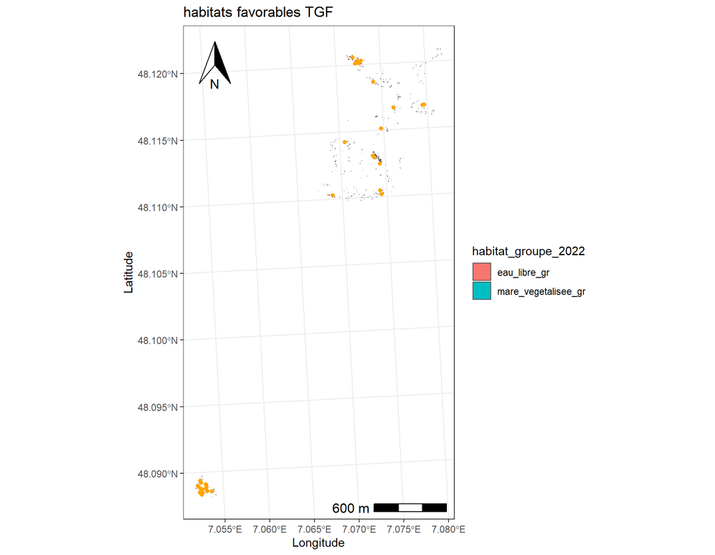